# Udacity Capstone Project - Costa Rican Household Poverty Prediction

### Introduction

This project's dataset was taken from a recent Kaggle competition that was held by the Inter-American Development Bank for aiding welfare care agencies to improve the existing PMT model for predicting the level of assistance required to give families in Costa Rica. I will use the train.csv data given in the competition as the input data for my project, and apply on it various pre-processing techniques as well as supervised learning algorithms, comparing their results.

### Data Exploration

```python
# Import libraries required for data exploration
import numpy as np
import pandas as pd
import matplotlib.pyplot as plt
import warnings
warnings.filterwarnings("ignore")

# Pretty display for notebooks
%matplotlib inline

# load the data
data = pd.read_csv("train.csv")

# Display the shape of the data
print ("Total rows*columns of the dataset: ", data.shape)

# The number of columns is high, we need to adjust the display (we sometimes display the columns as rows
# so I adjusted both parameters)
pd.set_option('display.max_columns', 200)
pd.set_option('display.max_rows', 200)

# Display a sample of it
display(data.head(n=5))
```

```
Total rows*columns of the dataset:  (9557, 143)
```

|  | Id | v2a1 | hacdor | rooms | hacapo | v14a | refrig | v18q | v18q1 | r4h1 | r4h2 | r4h3 | r4m1 | r4m2 | r4m3 | r4t1 | r4t2 | r4t3 | tamhog | tamviv | escolari | rez_esc | hhsize | paredblolad | paredzocalo | paredpreb | pareddes | paredmad | paredzinc | … |
| --- | --- | --- | --- | --- | --- | --- | --- | --- | --- | --- | --- | --- | --- | --- | --- | --- | --- | --- | --- | --- | --- | --- | --- | --- | --- | --- | --- | --- | --- | --- |
| 0 | ID_279628684 | 190000.0 | 0 | 3 | 0 | 1 | 1 | 0 | NaN | 0 | 1 | 1 | 0 | 0 | 0 | 0 | 1 | 1 | 1 | 1 | 10 | NaN | 1 | 1 | 0 | 0 | 0 | 0 | 0 | … |
| 1 | ID_f29eb3ddd | 135000.0 | 0 | 4 | 0 | 1 | 1 | 1 | 1.0 | 0 | 1 | 1 | 0 | 0 | 0 | 0 | 1 | 1 | 1 | 1 | 12 | NaN | 1 | 0 | 0 | 0 | 0 | 1 | 0 | … |
| 2 | ID_68de51c94 | NaN | 0 | 8 | 0 | 1 | 1 | 0 | NaN | 0 | 0 | 0 | 0 | 1 | 1 | 0 | 1 | 1 | 1 | 1 | 11 | NaN | 1 | 0 | 0 | 0 | 0 | 1 | 0 | … |
| 3 | ID_d671db89c | 180000.0 | 0 | 5 | 0 | 1 | 1 | 1 | 1.0 | 0 | 2 | 2 | 1 | 1 | 2 | 1 | 3 | 4 | 4 | 4 | 9 | 1.0 | 4 | 1 | 0 | 0 | 0 | 0 | 0 | … |
| 4 | ID_d56d6f5f5 | 180000.0 | 0 | 5 | 0 | 1 | 1 | 1 | 1.0 | 0 | 2 | 2 | 1 | 1 | 2 | 1 | 3 | 4 | 4 | 4 | 11 | NaN | 4 | 1 | 0 | 0 | 0 | 0 | 0 | … |

```python
# Show the data types of the columns
print(data.dtypes)
```

```
Id                  object
v2a1               float64
hacdor               int64
rooms                int64
hacapo               int64
v14a                 int64
refrig               int64
v18q                 int64
v18q1              float64
r4h1                 int64
r4h2                 int64
r4h3                 int64
r4m1                 int64
r4m2                 int64
r4m3                 int64
r4t1                 int64
r4t2                 int64
r4t3                 int64
tamhog               int64
tamviv               int64
escolari             int64
rez_esc            float64
hhsize               int64
paredblolad          int64
paredzocalo          int64
paredpreb            int64
pareddes             int64
paredmad             int64
paredzinc            int64
paredfibras          int64
paredother           int64
pisomoscer           int64
pisocemento          int64
pisoother            int64
pisonatur            int64
pisonotiene          int64
pisomadera           int64
techozinc            int64
techoentrepiso       int64
techocane            int64
```

[output cut: 89 more lines]

```
lugar6               int64
area1                int64
area2                int64
age                  int64
SQBescolari          int64
SQBage               int64
SQBhogar_total       int64
SQBedjefe            int64
SQBhogar_nin         int64
SQBovercrowding    float64
SQBdependency      float64
SQBmeaned          float64
agesq                int64
Target               int64
dtype: object
```

```python
# Get basic statistics of the data set, excluding object columns
data.describe(exclude = [ 'object'])
```

|  | v2a1 | hacdor | rooms | hacapo | v14a | refrig | v18q | v18q1 | r4h1 | r4h2 | r4h3 | r4m1 | r4m2 | r4m3 | r4t1 | r4t2 | r4t3 | tamhog | tamviv | escolari | rez_esc | hhsize | paredblolad | paredzocalo | paredpreb | pareddes | paredmad | paredzinc | paredfibras | … |
| --- | --- | --- | --- | --- | --- | --- | --- | --- | --- | --- | --- | --- | --- | --- | --- | --- | --- | --- | --- | --- | --- | --- | --- | --- | --- | --- | --- | --- | --- | --- |
| count | 2.697000e+03 | 9557.000000 | 9557.000000 | 9557.000000 | 9557.000000 | 9557.000000 | 9557.000000 | 2215.000000 | 9557.000000 | 9557.000000 | 9557.000000 | 9557.000000 | 9557.000000 | 9557.000000 | 9557.000000 | 9557.000000 | 9557.000000 | 9557.000000 | 9557.000000 | 9557.000000 | 1629.000000 | 9557.000000 | 9557.000000 | 9557.000000 | 9557.000000 | 9557.000000 | 9557.000000 | 9557.000000 | 9557.000000 | … |
| mean | 1.652316e+05 | 0.038087 | 4.955530 | 0.023648 | 0.994768 | 0.957623 | 0.231767 | 1.404063 | 0.385895 | 1.559171 | 1.945066 | 0.399184 | 1.661714 | 2.060898 | 0.785079 | 3.220885 | 4.005964 | 3.999058 | 4.094590 | 7.200272 | 0.459791 | 3.999058 | 0.594015 | 0.077744 | 0.188030 | 0.008580 | 0.115622 | 0.013079 | 0.001465 | … |
| std | 1.504571e+05 | 0.191417 | 1.468381 | 0.151957 | 0.072145 | 0.201459 | 0.421983 | 0.763131 | 0.680779 | 1.036574 | 1.188852 | 0.692460 | 0.933052 | 1.206172 | 1.047559 | 1.440995 | 1.771202 | 1.772216 | 1.876428 | 4.730877 | 0.946550 | 1.772216 | 0.491107 | 0.267782 | 0.390756 | 0.092235 | 0.319788 | 0.113621 | 0.038248 | … |
| min | 0.000000e+00 | 0.000000 | 1.000000 | 0.000000 | 0.000000 | 0.000000 | 0.000000 | 1.000000 | 0.000000 | 0.000000 | 0.000000 | 0.000000 | 0.000000 | 0.000000 | 0.000000 | 1.000000 | 1.000000 | 1.000000 | 1.000000 | 0.000000 | 0.000000 | 1.000000 | 0.000000 | 0.000000 | 0.000000 | 0.000000 | 0.000000 | 0.000000 | 0.000000 | … |
| 25% | 8.000000e+04 | 0.000000 | 4.000000 | 0.000000 | 1.000000 | 1.000000 | 0.000000 | 1.000000 | 0.000000 | 1.000000 | 1.000000 | 0.000000 | 1.000000 | 1.000000 | 0.000000 | 2.000000 | 3.000000 | 3.000000 | 3.000000 | 4.000000 | 0.000000 | 3.000000 | 0.000000 | 0.000000 | 0.000000 | 0.000000 | 0.000000 | 0.000000 | 0.000000 | … |
| 50% | 1.300000e+05 | 0.000000 | 5.000000 | 0.000000 | 1.000000 | 1.000000 | 0.000000 | 1.000000 | 0.000000 | 1.000000 | 2.000000 | 0.000000 | 1.000000 | 2.000000 | 0.000000 | 3.000000 | 4.000000 | 4.000000 | 4.000000 | 6.000000 | 0.000000 | 4.000000 | 1.000000 | 0.000000 | 0.000000 | 0.000000 | 0.000000 | 0.000000 | 0.000000 | … |
| 75% | 2.000000e+05 | 0.000000 | 6.000000 | 0.000000 | 1.000000 | 1.000000 | 0.000000 | 2.000000 | 1.000000 | 2.000000 | 3.000000 | 1.000000 | 2.000000 | 3.000000 | 1.000000 | 4.000000 | 5.000000 | 5.000000 | 5.000000 | 11.000000 | 1.000000 | 5.000000 | 1.000000 | 0.000000 | 0.000000 | 0.000000 | 0.000000 | 0.000000 | 0.000000 | … |
| max | 2.353477e+06 | 1.000000 | 11.000000 | 1.000000 | 1.000000 | 1.000000 | 1.000000 | 6.000000 | 5.000000 | 8.000000 | 8.000000 | 6.000000 | 6.000000 | 8.000000 | 7.000000 | 11.000000 | 13.000000 | 13.000000 | 15.000000 | 21.000000 | 5.000000 | 13.000000 | 1.000000 | 1.000000 | 1.000000 | 1.000000 | 1.000000 | 1.000000 | 1.000000 | … |

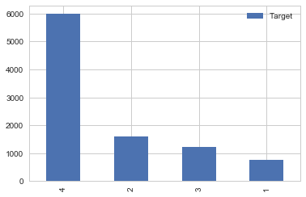

```python
# Let's check how the data distribution is by the target

target = data['Target'].value_counts().to_frame()
_  = target.plot(kind = 'bar')
```

Just by an initial look at the data, there seems to be several issues that needs to be addressed:

1. The target variable is unbalanced, as there are much more families targeted as Non-Vulnerable (4) compared to the other possible values.
2. Some of the columns are redundant (the SQB_xxx ones, the male\female columns) and should be removed
3. Some columns have missing values (e.g. rezesq, v18q1, v2a1) that should be handled
4. Some columns have mixed value types, and as a result, are described as type 'object'. For example, the 'dependency' column has in the sample data the following values: 'Yes', 'No' and '8'. Clearly this should be fixed.

Also note that the data contains rows for the head of the household as well as for the other inhabitants of the household. In this competition\analysis, we only need to address to the HEAD of the household (and of course verify that all such rows have a target value). This will be addressed below.

### Data Preparation

As denoted above, before starting to apply ML algorithms, we need to prepare the data firsthand. I am starting by dealing with the column types marked as 'object'

```python
data.select_dtypes('object').head(n=5)
```

|  | Id | idhogar | dependency | edjefe | edjefa |
| --- | --- | --- | --- | --- | --- |
| 0 | ID_279628684 | 21eb7fcc1 | no | 10 | no |
| 1 | ID_f29eb3ddd | 0e5d7a658 | 8 | 12 | no |
| 2 | ID_68de51c94 | 2c7317ea8 | 8 | no | 11 |
| 3 | ID_d671db89c | 2b58d945f | yes | 11 | no |
| 4 | ID_d56d6f5f5 | 2b58d945f | yes | 11 | no |

The "Id" and "idhogar" are indeed string values that represent IDs (the first one is the ID of the person, the 2nd one is the ID of the household). But the dependency, edjefe and edjefa columns should have numerical values.

Recap of the definition of those columns:

**dependency**: Dependency rate, calculated = (number of members of the household younger than 19 or older than 64)/(number of member of household between 19 and 64)

**edjefe**: years of education of male head of household, based on the interaction of escolari (years of education), head of household and gender, yes=1 and no=0

**edjefa**: years of education of female head of household, based on the interaction of escolari (years of education), head of household and gender, yes=1 and no=0

Which means we can replace the 'Yes' and 'No' values with 1 and 0 respectively

```python
mapping = {"yes": 1, "no": 0}

data['dependency'] = data['dependency'].replace(mapping).astype(np.float64)
data['edjefa'] = data['edjefa'].replace(mapping).astype(np.float64)
data['edjefe'] = data['edjefe'].replace(mapping).astype(np.float64)

data[['dependency', 'edjefa', 'edjefe']].describe()
```

|  | dependency | edjefa | edjefe |
| --- | --- | --- | --- |
| count | 9557.000000 | 9557.000000 | 9557.000000 |
| mean | 1.149550 | 2.896830 | 5.096788 |
| std | 1.605993 | 4.612056 | 5.246513 |
| min | 0.000000 | 0.000000 | 0.000000 |
| 25% | 0.333333 | 0.000000 | 0.000000 |
| 50% | 0.666667 | 0.000000 | 6.000000 |
| 75% | 1.333333 | 6.000000 | 9.000000 |
| max | 8.000000 | 21.000000 | 21.000000 |

Need to verify that all household entries have a head. according to the Kaggle competition, any entries without a head should be removed as their label cannot be resolved.

```python
# group by the household and count all the entries that have a head (parentesco1 == 1)
households_leader = data.groupby('idhogar')['parentesco1'].sum()

# Find households without a head
households_no_head = data.loc[data['idhogar'].isin(households_leader[households_leader == 0].index), :]
households_no_head = households_no_head['idhogar'].unique()

print('Number of households without a head is {}'.format(len(households_no_head)))
```

```
Number of households without a head is 15
```

We should remove the entries that have no household head:

```python
data = data[~data['idhogar'].isin(households_no_head)]
print ("Total rows*columns of the dataset after removing headless household entries: ", data.shape)
```

```
Total rows*columns of the dataset after removing headless household entries:  (9534, 143)
```

The next step would be to check which columns have missing values and how to handle those cases:

```python
# Number of missing in each column
missing = pd.DataFrame(data.isnull().sum()).rename(columns = {0: 'total missing'})

# Drop the columns that have no missing values
missing = missing[missing['total missing']>0]

missing.sort_values('total missing', ascending = False)
```

|  | total missing |
| --- | --- |
| rez_esc | 7921 |
| v18q1 | 7319 |
| v2a1 | 6843 |
| meaneduc | 5 |
| SQBmeaned | 5 |

It makes sense that meaneduc and SQBmeaned have identical missing values, since the 2nd feature is the square value of the 1st one. Also note that the number is relatively small (5). But for **v18q1**, **v2a1** and **rez_esc** the number of missing values is very high.

```python
# rez_esc is years behind in school, and according to the discussions in the competition (and real life...), this is
# relevant only for people in the age 7 to 19, so for other people we can set this to 0. Also the maximum value for this feature
# is 5, so we will update it here as well.

data.loc[((data['age'] > 19) | (data['age'] < 7)) & (data['rez_esc'].isnull()), 'rez_esc'] = 0
data.loc[data['rez_esc'] > 5, 'rez_esc'] = 5

# Let's see if there is any correlation between rez_esc and other "education related" columns:
data.loc[data['rez_esc'].isnull(), ['age', 'escolari', 'instlevel1', 'instlevel2', 'instlevel3', 'instlevel4', 'instlevel5', 'instlevel6',
                                    'instlevel7', 'instlevel8', 'instlevel9']].head(10)
```

|  | age | escolari | instlevel1 | instlevel2 | instlevel3 | instlevel4 | instlevel5 | instlevel6 | instlevel7 | instlevel8 | instlevel9 |
| --- | --- | --- | --- | --- | --- | --- | --- | --- | --- | --- | --- |
| 11 | 18 | 12 | 0 | 0 | 0 | 0 | 0 | 0 | 1 | 0 | 0 |
| 15 | 19 | 11 | 0 | 0 | 0 | 0 | 1 | 0 | 0 | 0 | 0 |
| 17 | 19 | 11 | 0 | 0 | 0 | 0 | 1 | 0 | 0 | 0 | 0 |
| 35 | 19 | 0 | 1 | 0 | 0 | 0 | 0 | 0 | 0 | 0 | 0 |
| 111 | 18 | 7 | 0 | 0 | 0 | 1 | 0 | 0 | 0 | 0 | 0 |
| 144 | 18 | 6 | 0 | 0 | 1 | 0 | 0 | 0 | 0 | 0 | 0 |
| 181 | 19 | 11 | 0 | 0 | 0 | 0 | 1 | 0 | 0 | 0 | 0 |
| 259 | 19 | 11 | 0 | 0 | 0 | 0 | 1 | 0 | 0 | 0 | 0 |
| 272 | 19 | 11 | 0 | 0 | 0 | 0 | 0 | 1 | 0 | 0 | 0 |
| 279 | 19 | 7 | 0 | 0 | 0 | 1 | 0 | 0 | 0 | 0 | 0 |

```python
# we can assume that in cases the cases above, we can use all the cases where escolari value is <= 12 to calculate
# the number of years behind in school as 12 - escolari (and again apply the 5 limit value)

data['12-escolari'] = 12 - data['escolari']
data.loc[data['12-escolari'] > 5, '12-escolari'] = 5
data.loc[data['12-escolari'] < 0, '12-escolari'] = 0
data.loc[data['rez_esc'].isnull() & data['escolari']<12, 'rez_esc'] = data['12-escolari']

data['rez_esc'].describe()
```

```
count    9534.000000
mean        3.402454
std         2.046270
min         0.000000
25%         1.000000
50%         5.000000
75%         5.000000
max         5.000000
Name: rez_esc, dtype: float64
```

Continuing to v18q1, we are now seeing that this value indicates the number of tablets the family owns. We have a boolean feature called v18q, which indicates whether the family has a tablet or not. We can try to see if from that we can resolve the missing values:

```python
data.groupby('v18q')['v18q1'].apply(lambda x: x.isnull().sum())
```

```
v18q
0    7319
1       0
Name: v18q1, dtype: int64
```

```python
# So we can fill in the missing values with zeros, since it's exact match to the families that have no tablet at all
data['v18q1'] = data['v18q1'].fillna(0)
```

Next on the list is the **v2a1** feature, which indicates the monthly rent payment. We can use the **tipovivi_xxx** features to verify that maybe this feature can be set to 0, in case rental is not relevant (e.g. the household owns the house)

```python
owner_column_names = [x for x in data if x.startswith('tipovivi')]

# check ownership variables values for home missing rent payments
data.loc[data['v2a1'].isnull(), owner_column_names].sum()
```

```
tipovivi1    5897
tipovivi2       0
tipovivi3       0
tipovivi4     163
tipovivi5     783
dtype: int64
```

```python
# So the above sums up exactly to 6843, which means we can safely set the value to 0 where missing, since tipovivi1, tipovivi4
# and tipovivi5 all account for cases where the house is NOT rented.

data.loc[:, 'v2a1'].fillna(0, inplace=True)
```

The last feature to handle is the meaneduc, which is defined as **average years of education for adults**. So we should check if those specific rows have missing values because these people did not go to school or their age is too young:

```python
data.loc[data['meaneduc'].isnull(), ['escolari', 'age', 'idhogar', 'parentesco1']]
```

|  | escolari | age | idhogar | parentesco1 |
| --- | --- | --- | --- | --- |
| 1291 | 10 | 18 | 1b31fd159 | 1 |
| 1840 | 6 | 18 | a874b7ce7 | 0 |
| 1841 | 4 | 18 | a874b7ce7 | 1 |
| 2049 | 12 | 19 | faaebf71a | 1 |
| 2050 | 12 | 19 | faaebf71a | 0 |

The age and years in school seems to be fine, but we do see that in all cases these are very young people. Let's check if they live with other adults in their houses:

```python
data.loc[data['idhogar'].isin(['1b31fd159', 'a874b7ce7', 'faaebf71a'])]
```

|  | Id | v2a1 | hacdor | rooms | hacapo | v14a | refrig | v18q | v18q1 | r4h1 | r4h2 | r4h3 | r4m1 | r4m2 | r4m3 | r4t1 | r4t2 | r4t3 | tamhog | tamviv | escolari | rez_esc | hhsize | paredblolad | paredzocalo | paredpreb | pareddes | paredmad | paredzinc | … |
| --- | --- | --- | --- | --- | --- | --- | --- | --- | --- | --- | --- | --- | --- | --- | --- | --- | --- | --- | --- | --- | --- | --- | --- | --- | --- | --- | --- | --- | --- | --- |
| 1291 | ID_bd8e11b0f | 0.0 | 0 | 7 | 0 | 1 | 1 | 0 | 0.0 | 0 | 0 | 0 | 0 | 1 | 1 | 0 | 1 | 1 | 1 | 1 | 10 | 2 | 1 | 0 | 0 | 0 | 0 | 1 | 0 | … |
| 1840 | ID_46ff87316 | 110000.0 | 0 | 1 | 0 | 1 | 1 | 0 | 0.0 | 0 | 1 | 1 | 0 | 1 | 1 | 0 | 2 | 2 | 2 | 2 | 6 | 5 | 2 | 1 | 0 | 0 | 0 | 0 | 0 | … |
| 1841 | ID_69f50bf3e | 110000.0 | 0 | 1 | 0 | 1 | 1 | 0 | 0.0 | 0 | 1 | 1 | 0 | 1 | 1 | 0 | 2 | 2 | 2 | 2 | 4 | 5 | 2 | 1 | 0 | 0 | 0 | 0 | 0 | … |
| 2049 | ID_db3168f9f | 180000.0 | 0 | 3 | 0 | 1 | 1 | 0 | 0.0 | 0 | 2 | 2 | 0 | 0 | 0 | 0 | 2 | 2 | 2 | 2 | 12 | 0 | 2 | 0 | 0 | 1 | 0 | 0 | 0 | … |
| 2050 | ID_2a7615902 | 180000.0 | 0 | 3 | 0 | 1 | 1 | 0 | 0.0 | 0 | 2 | 2 | 0 | 0 | 0 | 0 | 2 | 2 | 2 | 2 | 12 | 0 | 2 | 0 | 0 | 1 | 0 | 0 | 0 | … |

```python
# So it appears these are very young people living on their own. We can assume they did not go to school and set the mean
# education to 0.

data.loc[:, 'meaneduc'].fillna(0, inplace=True)
data.loc[:, 'SQBmeaned'].fillna(0, inplace=True)
```

#### Feature Removal

We can drop all the columns that are redundant: Id (unique ID) idhogar (unique ID) 12-escolari (synthetic column I created for imputation of rez_esc) square value columns (redundant because original columns exist) male (redundant. female column exists) and any other features which are highly correlated.

```python
# definitions based on https://www.kaggle.com/willkoehrsen/a-complete-introduction-and-walkthrough

from collections import Counter

id_ = ['Id', 'idhogar', 'Target']

ind_bool = ['v18q', 'dis', 'male', 'female', 'estadocivil1', 'estadocivil2', 'estadocivil3',
            'estadocivil4', 'estadocivil5', 'estadocivil6', 'estadocivil7',
            'parentesco1', 'parentesco2',  'parentesco3', 'parentesco4', 'parentesco5',
            'parentesco6', 'parentesco7', 'parentesco8',  'parentesco9', 'parentesco10',
            'parentesco11', 'parentesco12', 'instlevel1', 'instlevel2', 'instlevel3',
            'instlevel4', 'instlevel5', 'instlevel6', 'instlevel7', 'instlevel8',
            'instlevel9', 'mobilephone']

ind_ordered = ['rez_esc', 'escolari', 'age']

hh_bool = ['hacdor', 'hacapo', 'v14a', 'refrig', 'paredblolad', 'paredzocalo',
           'paredpreb','pisocemento', 'pareddes', 'paredmad',
           'paredzinc', 'paredfibras', 'paredother', 'pisomoscer', 'pisoother',
           'pisonatur', 'pisonotiene', 'pisomadera',
           'techozinc', 'techoentrepiso', 'techocane', 'techootro', 'cielorazo',
           'abastaguadentro', 'abastaguafuera', 'abastaguano',
            'public', 'planpri', 'noelec', 'coopele', 'sanitario1',
           'sanitario2', 'sanitario3', 'sanitario5',   'sanitario6',
           'energcocinar1', 'energcocinar2', 'energcocinar3', 'energcocinar4',
           'elimbasu1', 'elimbasu2', 'elimbasu3', 'elimbasu4',
           'elimbasu5', 'elimbasu6', 'epared1', 'epared2', 'epared3',
           'etecho1', 'etecho2', 'etecho3', 'eviv1', 'eviv2', 'eviv3',
           'tipovivi1', 'tipovivi2', 'tipovivi3', 'tipovivi4', 'tipovivi5',
           'computer', 'television', 'lugar1', 'lugar2', 'lugar3',
           'lugar4', 'lugar5', 'lugar6', 'area1', 'area2']

hh_ordered = [ 'rooms', 'r4h1', 'r4h2', 'r4h3', 'r4m1','r4m2','r4m3', 'r4t1',  'r4t2',
              'r4t3', 'v18q1', 'tamhog','tamviv','hhsize','hogar_nin',
              'hogar_adul','hogar_mayor','hogar_total',  'bedrooms', 'qmobilephone']

hh_cont = ['v2a1', 'dependency', 'edjefe', 'edjefa', 'meaneduc', 'overcrowding']

sqr_ = ['SQBescolari', 'SQBage', 'SQBhogar_total', 'SQBedjefe',
        'SQBhogar_nin', 'SQBovercrowding', 'SQBdependency', 'SQBmeaned', 'agesq']

synthetic = ['12-escolari']

x = ind_bool + ind_ordered + id_ + hh_bool + hh_ordered + hh_cont + sqr_ + synthetic

print('There are no repeats: ', np.all(np.array(list(Counter(x).values())) == 1))
print('We covered every variable: ', len(x) == data.shape[1])
```

```
There are no repeats:  True
We covered every variable:  True
```

```python
# drop square variables and synthetic variables

data = data.drop(columns = sqr_ + synthetic)
data.shape
```

```
(9534, 134)
```

In the Kaggle competition, the predictions (score) would be only on the rows of the households, so we need to extracta from the data only the rows that represent households. We should also check that their Target distribution is similar to that of the original data.

We'll add to those entries the aggregations of the other household members later.

##### Household data

```python
heads = data.loc[data['parentesco1'] == 1, :]
heads = heads[id_ + hh_bool + hh_cont + hh_ordered]
print ("Total rows*columns of the heads: ", heads.shape)
```

```
Total rows*columns of the heads:  (2973, 98)
```

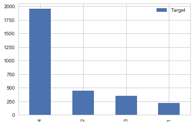

```python
target = heads['Target'].value_counts().to_frame()
_  = target.plot(kind = 'bar')
```

```python
# find and drop correlated features.
# based on https://chrisalbon.com/machine_learning/feature_selection/drop_highly_correlated_features/

# Create correlation matrix
corr_matrix = heads.corr().abs()

# Select upper triangle of correlation matrix
upper = corr_matrix.where(np.triu(np.ones(corr_matrix.shape), k=1).astype(np.bool))

# Find index of feature columns with correlation greater than 0.95
to_drop = [column for column in upper.columns if any(upper[column] > 0.95)]

to_drop
```

```
['coopele', 'area2', 'tamhog', 'hhsize', 'hogar_total']
```

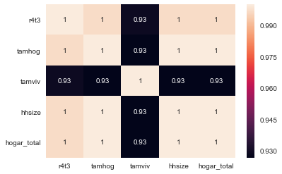

```python
import seaborn as sb

sb.heatmap(corr_matrix.loc[corr_matrix['tamhog'].abs() > 0.9, corr_matrix['tamhog'].abs() > 0.9],
            annot=True);
```

If we look at the description of the columns given in Kaggle, this makes sense: r4t3 = Total persons in the household tamhog = size of the household tamviv = number of persons living in the household hhsize = household size hogar_total = of total individuals in the household

So some of the features have perfect correlation: r4t3, hogar_total, hhsize and tamhog. However, tamviv may be slightly different compared to these 4 features, because there could be other people living in the house which are not family members. So i will keep tamviv and tamhog.

```python
heads = heads.drop(columns = ['hhsize', 'hogar_total', 'r4t3'])
```

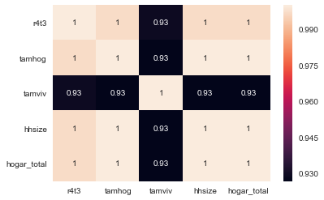

```python
sb.heatmap(corr_matrix.loc[corr_matrix['tamhog'].abs() > 0.9, corr_matrix['tamhog'].abs() > 0.9],
            annot=True);
```

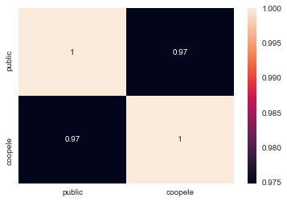

```python
sb.heatmap(corr_matrix.loc[corr_matrix['coopele'].abs() > 0.9, corr_matrix['coopele'].abs() > 0.9],
            annot=True);
```

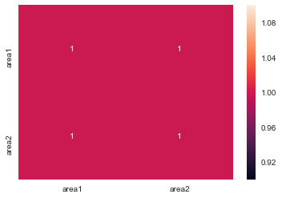

```python
sb.heatmap(corr_matrix.loc[corr_matrix['area2'].abs() > 0.9, corr_matrix['area2'].abs() > 0.9],
            annot=True);
```

So 'coopele' and 'public' are highly correlated, which also makes sense (since public electricity is usually a cooperative), so i will drop public.

In addition, area1 and area2 are exactly opposites (rural or urban location), so i will drop area2.

```python
heads = heads.drop(columns = ['public', 'area2'])
```

##### Individual data

```python
individuals = data[id_ + ind_bool + ind_ordered]
individuals.shape
```

```
(9534, 39)
```

```python
# Create correlation matrix
corr_matrix = individuals.corr().abs()

# Select upper triangle of correlation matrix
upper = corr_matrix.where(np.triu(np.ones(corr_matrix.shape), k=1).astype(np.bool))

# Find index of feature columns with correlation greater than 0.95
to_drop = [column for column in upper.columns if any(upper[column] > 0.95)]

to_drop
```

```
['female']
```

I actually observed this before just by reading the column descriptions... There is both 'male' and 'female' columns, so we can remove the 'male' column altogether.

```python
individuals = individuals.drop(columns = 'male')
```

```python
# looking at a sample of individuals of a specific household
individuals.loc[individuals['idhogar'] == '003123ec2']
```

|  | Id | idhogar | Target | v18q | dis | female | estadocivil1 | estadocivil2 | estadocivil3 | estadocivil4 | estadocivil5 | estadocivil6 | estadocivil7 | parentesco1 | parentesco2 | parentesco3 | parentesco4 | parentesco5 | parentesco6 | parentesco7 | parentesco8 | parentesco9 | parentesco10 | parentesco11 | parentesco12 | instlevel1 | instlevel2 | instlevel3 | instlevel4 | … |
| --- | --- | --- | --- | --- | --- | --- | --- | --- | --- | --- | --- | --- | --- | --- | --- | --- | --- | --- | --- | --- | --- | --- | --- | --- | --- | --- | --- | --- | --- | --- |
| 8159 | ID_55199c2f3 | 003123ec2 | 2 | 0 | 0 | 1 | 0 | 1 | 0 | 0 | 0 | 0 | 0 | 0 | 1 | 0 | 0 | 0 | 0 | 0 | 0 | 0 | 0 | 0 | 0 | 0 | 0 | 0 | 1 | … |
| 8160 | ID_5bef9b553 | 003123ec2 | 2 | 0 | 0 | 0 | 0 | 1 | 0 | 0 | 0 | 0 | 0 | 1 | 0 | 0 | 0 | 0 | 0 | 0 | 0 | 0 | 0 | 0 | 0 | 0 | 0 | 1 | 0 | … |
| 8161 | ID_079963679 | 003123ec2 | 2 | 0 | 0 | 0 | 1 | 0 | 0 | 0 | 0 | 0 | 0 | 0 | 0 | 1 | 0 | 0 | 0 | 0 | 0 | 0 | 0 | 0 | 0 | 1 | 0 | 0 | 0 | … |
| 8162 | ID_99c9bcea5 | 003123ec2 | 2 | 0 | 0 | 0 | 1 | 0 | 0 | 0 | 0 | 0 | 0 | 0 | 0 | 1 | 0 | 0 | 0 | 0 | 0 | 0 | 0 | 0 | 0 | 1 | 0 | 0 | 0 | … |

```python
# display the complete column names list for the individual records
list(individuals)
```

```
['Id',
 'idhogar',
 'Target',
 'v18q',
 'dis',
 'female',
 'estadocivil1',
 'estadocivil2',
 'estadocivil3',
 'estadocivil4',
 'estadocivil5',
 'estadocivil6',
 'estadocivil7',
 'parentesco1',
 'parentesco2',
 'parentesco3',
 'parentesco4',
 'parentesco5',
 'parentesco6',
 'parentesco7',
 'parentesco8',
 'parentesco9',
 'parentesco10',
 'parentesco11',
 'parentesco12',
 'instlevel1',
 'instlevel2',
 'instlevel3',
 'instlevel4',
 'instlevel5',
 'instlevel6',
 'instlevel7',
 'instlevel8',
 'instlevel9',
 'mobilephone',
 'rez_esc',
 'escolari',
 'age']
```

Now in order to aggregate, I need to make up the relevant aggregation functions for each type of column values: For boolean (0 or 1) values, the **sum** function would be best used. For continous features (**rez_esc**, **escolary** and **age**) using **mean**, **min** and **max**.

Note that std will NOT be used, because for households with 1 row (person), pandas std will return NaN value (There are 388 such cases in the dataset).

See more information at: https://stackoverflow.com/questions/50306914/pandas-groupby-agg-std-nan

```python
# Group and aggregate

aggregations = {"v18q": {"v18q_sum": "sum"},
                "dis": {"dis_sum": "sum"},
                "female": {"female_sum": "sum"},
                "estadocivil1": {"estadocivil1_sum": "sum"},
                "estadocivil2": {"estadocivil2_sum": "sum"},
                "estadocivil3": {"estadocivil3_sum": "sum"},
                "estadocivil4": {"estadocivil4_sum": "sum"},
                "estadocivil5": {"estadocivil5_sum": "sum"},
                "estadocivil6": {"estadocivil6_sum": "sum"},
                "estadocivil7": {"estadocivil7_sum": "sum"},
                "parentesco1": {"parentesco1_sum": "sum"},
                "parentesco2": {"parentesco2_sum": "sum"},
                "parentesco3": {"parentesco3_sum": "sum"},
                "parentesco4": {"parentesco4_sum": "sum"},
                "parentesco5": {"parentesco5_sum": "sum"},
                "parentesco6": {"parentesco6_sum": "sum"},
                "parentesco7": {"parentesco7_sum": "sum"},
                "parentesco8": {"parentesco8_sum": "sum"},
                "parentesco9": {"parentesco9_sum": "sum"},
                "parentesco10": {"parentesco10_sum": "sum"},
                "parentesco11": {"parentesco11_sum": "sum"},
                "parentesco12": {"parentesco12_sum": "sum"},
                "instlevel1": {"instlevel1_sum": "sum"},
                "instlevel2": {"instlevel2_sum": "sum"},
                "instlevel3": {"instlevel3_sum": "sum"},
                "instlevel4": {"instlevel4_sum": "sum"},
                "instlevel5": {"instlevel5_sum": "sum"},
                "instlevel6": {"instlevel6_sum": "sum"},
                "instlevel7": {"instlevel7_sum": "sum"},
                "instlevel8": {"instlevel8_sum": "sum"},
                "instlevel9": {"instlevel9_sum": "sum"},
                "mobilephone": {"mobilephone_sum": "sum"},
                "rez_esc": {"rez_esc_mean": "mean", "rez_esc_min" : "min", "rez_esc_max" : "max"},
                "escolari": {"escolari_mean": "mean", "escolari_min" : "min", "escolari_max" : "max"},
                "age": {"age_mean": "mean", "age_min" : "min", "age_max" : "max"},
               }

individuals_aggregated = individuals.drop(columns = 'Target').groupby('idhogar').agg(aggregations)
individuals_aggregated.columns = individuals_aggregated.columns.droplevel(0)
individuals_aggregated.head()
```

| idhogar | v18q_sum | dis_sum | female_sum | estadocivil1_sum | estadocivil2_sum | estadocivil3_sum | estadocivil4_sum | estadocivil5_sum | estadocivil6_sum | estadocivil7_sum | parentesco1_sum | parentesco2_sum | parentesco3_sum | parentesco4_sum | parentesco5_sum | parentesco6_sum | parentesco7_sum | parentesco8_sum | parentesco9_sum | parentesco10_sum | parentesco11_sum | parentesco12_sum | instlevel1_sum | instlevel2_sum | instlevel3_sum | instlevel4_sum | instlevel5_sum | instlevel6_sum | instlevel7_sum | … |
| --- | --- | --- | --- | --- | --- | --- | --- | --- | --- | --- | --- | --- | --- | --- | --- | --- | --- | --- | --- | --- | --- | --- | --- | --- | --- | --- | --- | --- | --- | --- |
| 001ff74ca | 2 | 0 | 2 | 1 | 0 | 0 | 0 | 1 | 0 | 0 | 1 | 0 | 1 | 0 | 0 | 0 | 0 | 0 | 0 | 0 | 0 | 0 | 1 | 0 | 0 | 0 | 0 | 0 | 0 | … |
| 003123ec2 | 0 | 0 | 1 | 2 | 2 | 0 | 0 | 0 | 0 | 0 | 1 | 1 | 2 | 0 | 0 | 0 | 0 | 0 | 0 | 0 | 0 | 0 | 2 | 0 | 1 | 1 | 0 | 0 | 0 | … |
| 004616164 | 0 | 0 | 0 | 0 | 0 | 0 | 0 | 0 | 1 | 1 | 1 | 0 | 1 | 0 | 0 | 0 | 0 | 0 | 0 | 0 | 0 | 0 | 0 | 1 | 0 | 0 | 1 | 0 | 0 | … |
| 004983866 | 0 | 0 | 1 | 0 | 0 | 0 | 0 | 0 | 1 | 1 | 1 | 0 | 0 | 0 | 0 | 1 | 0 | 0 | 0 | 0 | 0 | 0 | 0 | 0 | 0 | 2 | 0 | 0 | 0 | … |
| 005905417 | 0 | 0 | 1 | 1 | 0 | 0 | 0 | 1 | 0 | 1 | 1 | 0 | 2 | 0 | 0 | 0 | 0 | 0 | 0 | 0 | 0 | 0 | 1 | 0 | 0 | 2 | 0 | 0 | 0 | … |

```python
# now merge it back to the heads for the final input
# Merge on the household id
classfier_input = heads.merge(individuals_aggregated, on = 'idhogar', how = 'left')

# remove ID columns

classfier_input = classfier_input.drop(columns = ['Id', 'idhogar'])
print('Classifier input Rows*Columns:', classfier_input.shape)
```

```
Classifier input Rows*Columns: (2973, 132)
```

```python
classfier_input.head()
```

|  | Target | hacdor | hacapo | v14a | refrig | paredblolad | paredzocalo | paredpreb | pisocemento | pareddes | paredmad | paredzinc | paredfibras | paredother | pisomoscer | pisoother | pisonatur | pisonotiene | pisomadera | techozinc | techoentrepiso | techocane | techootro | cielorazo | abastaguadentro | abastaguafuera | abastaguano | planpri | noelec | … |
| --- | --- | --- | --- | --- | --- | --- | --- | --- | --- | --- | --- | --- | --- | --- | --- | --- | --- | --- | --- | --- | --- | --- | --- | --- | --- | --- | --- | --- | --- | --- |
| 0 | 4 | 0 | 0 | 1 | 1 | 1 | 0 | 0 | 0 | 0 | 0 | 0 | 0 | 0 | 1 | 0 | 0 | 0 | 0 | 0 | 1 | 0 | 0 | 1 | 1 | 0 | 0 | 0 | 0 | … |
| 1 | 4 | 0 | 0 | 1 | 1 | 0 | 0 | 0 | 0 | 0 | 1 | 0 | 0 | 0 | 0 | 0 | 0 | 0 | 1 | 1 | 0 | 0 | 0 | 1 | 1 | 0 | 0 | 0 | 0 | … |
| 2 | 4 | 0 | 0 | 1 | 1 | 0 | 0 | 0 | 0 | 0 | 1 | 0 | 0 | 0 | 1 | 0 | 0 | 0 | 0 | 1 | 0 | 0 | 0 | 1 | 1 | 0 | 0 | 0 | 0 | … |
| 3 | 4 | 0 | 0 | 1 | 1 | 1 | 0 | 0 | 0 | 0 | 0 | 0 | 0 | 0 | 1 | 0 | 0 | 0 | 0 | 1 | 0 | 0 | 0 | 1 | 1 | 0 | 0 | 0 | 0 | … |
| 4 | 4 | 1 | 0 | 1 | 1 | 1 | 0 | 0 | 0 | 0 | 0 | 0 | 0 | 0 | 1 | 0 | 0 | 0 | 0 | 1 | 0 | 0 | 0 | 1 | 1 | 0 | 0 | 0 | 0 | … |

```python
classfier_input.describe()
```

|  | Target | hacdor | hacapo | v14a | refrig | paredblolad | paredzocalo | paredpreb | pisocemento | pareddes | paredmad | paredzinc | paredfibras | paredother | pisomoscer | pisoother | pisonatur | pisonotiene | pisomadera | techozinc | techoentrepiso | techocane | techootro | cielorazo | abastaguadentro | abastaguafuera | abastaguano | planpri | noelec | … |
| --- | --- | --- | --- | --- | --- | --- | --- | --- | --- | --- | --- | --- | --- | --- | --- | --- | --- | --- | --- | --- | --- | --- | --- | --- | --- | --- | --- | --- | --- | --- |
| count | 2973.000000 | 2973.000000 | 2973.000000 | 2973.000000 | 2973.000000 | 2973.000000 | 2973.000000 | 2973.000000 | 2973.000000 | 2973.000000 | 2973.000000 | 2973.000000 | 2973.000000 | 2973.000000 | 2973.000000 | 2973.000000 | 2973.000000 | 2973.000000 | 2973.000000 | 2973.000000 | 2973.000000 | 2973.000000 | 2973.000000 | 2973.000000 | 2973.000000 | 2973.000000 | 2973.000000 | 2973.000000 | 2973.000000 | … |
| mean | 3.359233 | 0.021191 | 0.012109 | 0.994282 | 0.952573 | 0.603431 | 0.077699 | 0.183317 | 0.212916 | 0.008409 | 0.114026 | 0.010091 | 0.001682 | 0.001345 | 0.706694 | 0.000673 | 0.001009 | 0.012782 | 0.065927 | 0.966700 | 0.021527 | 0.003027 | 0.002355 | 0.691557 | 0.967373 | 0.028927 | 0.003700 | 0.000673 | 0.003027 | … |
| std | 0.987870 | 0.144044 | 0.109391 | 0.075414 | 0.212586 | 0.489267 | 0.267743 | 0.386991 | 0.409438 | 0.091330 | 0.317897 | 0.099962 | 0.040982 | 0.036662 | 0.455354 | 0.025933 | 0.031755 | 0.112350 | 0.248196 | 0.179448 | 0.145158 | 0.054946 | 0.048474 | 0.461928 | 0.177688 | 0.167630 | 0.060725 | 0.025933 | 0.054946 | … |
| min | 1.000000 | 0.000000 | 0.000000 | 0.000000 | 0.000000 | 0.000000 | 0.000000 | 0.000000 | 0.000000 | 0.000000 | 0.000000 | 0.000000 | 0.000000 | 0.000000 | 0.000000 | 0.000000 | 0.000000 | 0.000000 | 0.000000 | 0.000000 | 0.000000 | 0.000000 | 0.000000 | 0.000000 | 0.000000 | 0.000000 | 0.000000 | 0.000000 | 0.000000 | … |
| 25% | 3.000000 | 0.000000 | 0.000000 | 1.000000 | 1.000000 | 0.000000 | 0.000000 | 0.000000 | 0.000000 | 0.000000 | 0.000000 | 0.000000 | 0.000000 | 0.000000 | 0.000000 | 0.000000 | 0.000000 | 0.000000 | 0.000000 | 1.000000 | 0.000000 | 0.000000 | 0.000000 | 0.000000 | 1.000000 | 0.000000 | 0.000000 | 0.000000 | 0.000000 | … |
| 50% | 4.000000 | 0.000000 | 0.000000 | 1.000000 | 1.000000 | 1.000000 | 0.000000 | 0.000000 | 0.000000 | 0.000000 | 0.000000 | 0.000000 | 0.000000 | 0.000000 | 1.000000 | 0.000000 | 0.000000 | 0.000000 | 0.000000 | 1.000000 | 0.000000 | 0.000000 | 0.000000 | 1.000000 | 1.000000 | 0.000000 | 0.000000 | 0.000000 | 0.000000 | … |
| 75% | 4.000000 | 0.000000 | 0.000000 | 1.000000 | 1.000000 | 1.000000 | 0.000000 | 0.000000 | 0.000000 | 0.000000 | 0.000000 | 0.000000 | 0.000000 | 0.000000 | 1.000000 | 0.000000 | 0.000000 | 0.000000 | 0.000000 | 1.000000 | 0.000000 | 0.000000 | 0.000000 | 1.000000 | 1.000000 | 0.000000 | 0.000000 | 0.000000 | 0.000000 | … |
| max | 4.000000 | 1.000000 | 1.000000 | 1.000000 | 1.000000 | 1.000000 | 1.000000 | 1.000000 | 1.000000 | 1.000000 | 1.000000 | 1.000000 | 1.000000 | 1.000000 | 1.000000 | 1.000000 | 1.000000 | 1.000000 | 1.000000 | 1.000000 | 1.000000 | 1.000000 | 1.000000 | 1.000000 | 1.000000 | 1.000000 | 1.000000 | 1.000000 | 1.000000 | … |

```
count       2973.000000
mean       46389.874201
std       112755.371100
min            0.000000
25%            0.000000
50%            0.000000
75%        40000.000000
max      2353477.000000
Name: v2a1, dtype: object
```

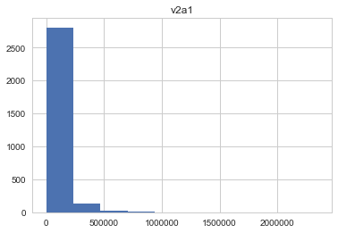

```python
# check for data skew of v2a1, and fix it

print(classfier_input['v2a1'].describe().apply(lambda x: format(x, 'f')))
v2a1 = classfier_input['v2a1'].to_frame()
_  = v2a1.hist(bins = 10)
```

```
count    2973.000000
mean        3.200900
std         5.243638
min         0.000000
25%         0.000000
50%         0.000000
75%        10.596660
max        14.671405
Name: v2a1, dtype: object
```

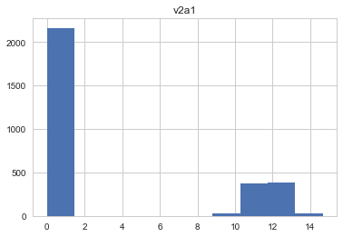

```python
classfier_input['v2a1'] = classfier_input['v2a1'].apply(lambda x: np.log(x + 1))
print(classfier_input['v2a1'].describe().apply(lambda x: format(x, 'f')))
v2a1 = classfier_input['v2a1'].to_frame()
_  = v2a1.hist(bins = 10)
```

### Exploratory Visualization

Now that our features have been cleaned from abnormalities, missing values are fixed, and inidividual data aggregated to the household data, we can explore some of the relations\characteristics between various feature and the target, just to get an initial analysis of what might predict well our target

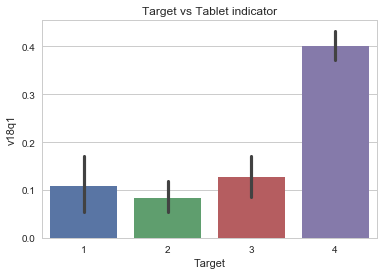

```python
# we expect that in poverty\extreme poverty most families will NOT own a tablet
sb.set(style="whitegrid")
ax = sb.barplot(x="Target", y="v18q1", data=classfier_input).set_title('Target vs Tablet indicator')
```

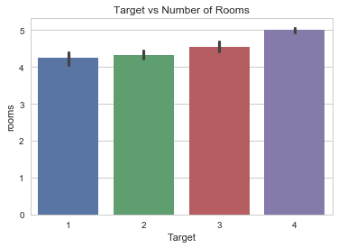

```python
# we expect that families in exterme poverty will live in smaller number of rooms but actually according to the data
# the difference is much smaller
sb.set(style="whitegrid")
ax = sb.barplot(x="Target", y="rooms", data=classfier_input).set_title('Target vs Number of Rooms')
```

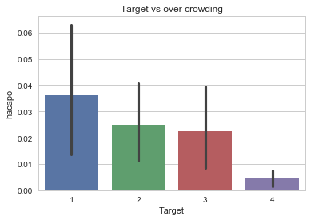

```python
# however, they are definitely more over crowded than other families
ax = sb.barplot(x="Target", y="hacapo", data=classfier_input).set_title('Target vs over crowding')
```

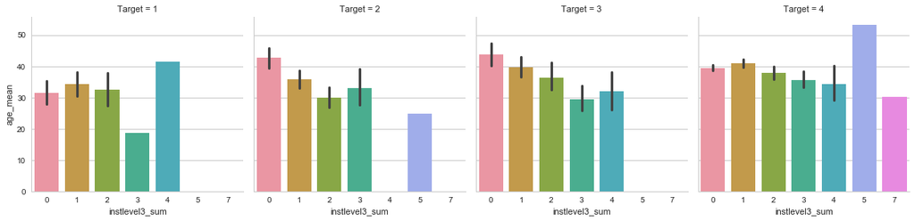

```python
# let's also explore the connection between education, age and poverty, starting with people who complete primary school
cols = ['instlevel3_sum', 'age_mean', 'Target']
sb.factorplot("instlevel3_sum", "age_mean", col="Target", data=classfier_input[cols], kind="bar")
```

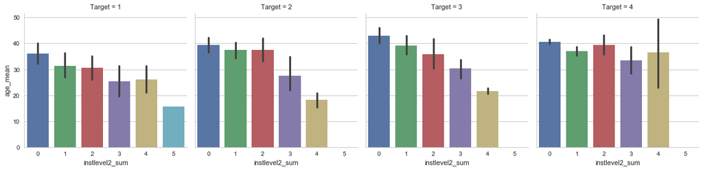

```python
# we saw above that for extreme poverty cases, the total number of years completed in primary school
# is small, while for the higher target values (3 and 4) we have a total of more people that completed primary school.
# this makes sense.

# now let's check how this looks for people which did not complete primary school
cols = ['instlevel2_sum', 'age_mean', 'Target']
sb.factorplot("instlevel2_sum", "age_mean", col="Target", data=classfier_input[cols], kind="bar")

# note that for the extreme poverty the values are higher compared to the other categories (sum = 5 is only there)
# also note that the average age of such households is relatively lower compared ot targets 3 and 4.
# so we are talking about relatively young aged families in extreme poverty.
```

### Data scaling and preparing train & test set

```python
from sklearn.pipeline import Pipeline
from sklearn.preprocessing import MinMaxScaler
from sklearn.model_selection import train_test_split

# Split the data into features and target label
target_labels = classfier_input['Target']
features = classfier_input.drop('Target', axis = 1)

# minMaxScaler on numerical features using:
pipeline = Pipeline([('scaler', MinMaxScaler())])
scaled_features = pipeline.fit_transform(features)

# create train and test data
X_train, X_test, y_train, y_test = train_test_split(scaled_features,
                                                    target_labels,
                                                    test_size = 0.2,
                                                    random_state = 42)

# Show the results of the split
print("Training set has {} samples.".format(X_train.shape[0]))
print("Testing set has {} samples.".format(X_test.shape[0]))
```

```
Training set has 2378 samples.
Testing set has 595 samples.
```

### Scorer and running classifiers

```python
from sklearn.metrics import f1_score, make_scorer, confusion_matrix, balanced_accuracy_score
from sklearn.model_selection import GridSearchCV
from time import time


# define the scorer object
f1_weighted_scorer = make_scorer(f1_score, average = 'weighted')

# define the classifier execution function
def train_predict(clf, scorer, hyper_parameters, X_train, y_train, X_test, y_test):

    results = {}

    grid_obj = GridSearchCV(estimator=clf, param_grid=hyper_parameters, scoring=scorer)

    # training and finding best model using grid search
    start = time()
    grid_fit = grid_obj.fit(X_train, y_train)
    end = time()
    results['train_time'] = end - start

    # extract the best classifier and use it to make the predictions
    best_clf = grid_fit.best_estimator_
    start = time()
    y_pred = best_clf.predict(X_test)
    end = time()
    results['pred_time'] = end - start

    # calculate accuracy, weighted F1-score and confusion matrix
    results['accuracy'] = balanced_accuracy_score(y_test, y_pred)
    results['f1_score'] = f1_score(y_test, y_pred, average='weighted')
    results['cm'] = confusion_matrix(y_test, y_pred)
    results['best_params'] = grid_fit.best_params_

    print("completed training using {} classifier".format(clf.__class__.__name__))

    # Return the results
    return results
```

### The Naive Predictor

```python
from sklearn.base import BaseEstimator
class NaiveClassifier(BaseEstimator):

    def fit(self, X, y):
        return self

    def predict(self, X):
        return np.full(X.shape[0], 4, dtype=np.int64)
```

```python
# function to plot the confusion matrix,
# taken from https://scikit-learn.org/stable/auto_examples/model_selection/plot_confusion_matrix.html
import itertools

def plot_confusion_matrix(cm, classifierName,
                          normalize=False,
                          cmap=plt.cm.Blues):

    title= classifierName + ' Confusion matrix'
    classes = ['Extreme', 'Moderate', 'Vulnerable', 'Non-Vulnerable']

    """
    This function prints and plots the confusion matrix.
    Normalization can be applied by setting `normalize=True`.
    """
    if normalize:
        cm = cm.astype('float') / cm.sum(axis=1)[:, np.newaxis]
        print("Normalized confusion matrix")
    else:
        print('Confusion matrix, without normalization')

    print(cm)

    plt.imshow(cm, interpolation='nearest', cmap=cmap)
    plt.title(title)
    plt.colorbar()
    tick_marks = np.arange(len(classes))
    plt.xticks(tick_marks, classes, rotation=45)
    plt.yticks(tick_marks, classes)

    fmt = '.2f' if normalize else 'd'
    thresh = cm.max() / 2.
    for i, j in itertools.product(range(cm.shape[0]), range(cm.shape[1])):
        plt.text(j, i, format(cm[i, j], fmt),
                 horizontalalignment="center",
                 color="white" if cm[i, j] > thresh else "black")

    plt.ylabel('True label')
    plt.xlabel('Predicted label')
    plt.tight_layout()

def output_classifier_results(clf_name, results):

    print('train_time: {}'.format(results['train_time']))
    print('pred_time: {}'.format(results['pred_time']))
    print('accuracy: {}'.format(results['accuracy']))
    print('f1_score: {}'.format(results['f1_score']))
    plot_confusion_matrix(results['cm'], clf_name)
```

```
completed training using NaiveClassifier classifier
train_time: 0.01999664306640625
pred_time: 0.0
accuracy: 0.25
f1_score: 0.5062823495077295
Confusion matrix, without normalization
[[  0   0   0  43]
 [  0   0   0  91]
 [  0   0   0  77]
 [  0   0   0 384]]
```

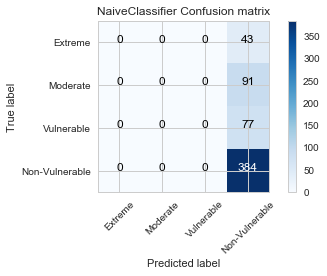

```python
naive_clf_res = train_predict(NaiveClassifier(),
                              f1_weighted_scorer,
                              {}, X_train, y_train, X_test, y_test)

output_classifier_results('NaiveClassifier', naive_clf_res)
```

So the Naive predictor is poorly accurate (which makes sense, because it predicts always '4' which is the most popular target), but its weighted F1 score is not so good (0.50). Let's see how other algorithms work out for us.

Note that the "original" accuracy score was the Naive predictor was *0.6453781512605042* which is relatively good. But once you use the weighted accuracy score, you see that it is 0.25 (since it predicted 100% correct only for 1 out of the 4 target classes).

### Supervised algorithms

[output not shown]

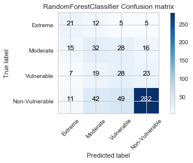

```python
# Random Forest

from sklearn.ensemble import RandomForestClassifier

rf_hyper_parameters = {'n_estimators': [50, 150],
                       'criterion': ['gini', 'entropy'],
                       'max_depth': [2, 4, 8],
                       'min_samples_split': [2, 4, 8],
                       'min_samples_leaf': [2, 4, 8]}

# using class_weight = 'balanced' produced better accuracy score because of the data imbalance we have
rf_clf_res = train_predict(RandomForestClassifier(random_state = 42, class_weight = 'balanced'),
                              f1_weighted_scorer,
                              rf_hyper_parameters, X_train, y_train, X_test, y_test)

output_classifier_results('RandomForestClassifier', rf_clf_res)
```

```
completed training using GaussianNB classifier
train_time: 0.10699319839477539
pred_time: 0.0010039806365966797
accuracy: 0.3117617907770524
f1_score: 0.2249774956698472
Confusion matrix, without normalization
[[  6   1  36   0]
 [ 12   1  76   2]
 [  4   0  72   1]
 [ 18   1 303  62]]
```

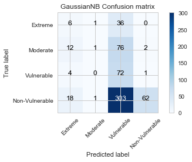

```python
# Gaussian Naïve Bayes

from sklearn.naive_bayes import GaussianNB

# we will probably not get good results here, since the features likelihood is not Gaussian
gnb_clf_res = train_predict(GaussianNB(),
                            f1_weighted_scorer,
                            {}, X_train, y_train, X_test, y_test)

output_classifier_results('GaussianNB', gnb_clf_res)
```

```
completed training using DecisionTreeClassifier classifier
train_time: 5.605004787445068
pred_time: 0.0
accuracy: 0.4601136206332427
f1_score: 0.5322853934601476
Confusion matrix, without normalization
[[ 20  14   6   3]
 [ 25  39  21   6]
 [ 13  21  34   9]
 [ 47  65  78 194]]
```

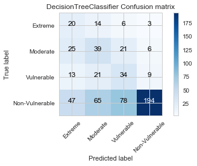

```python
# decision tree
from sklearn.tree import DecisionTreeClassifier

dtc_hyper_parameters = {'criterion': ['gini', 'entropy'],
                       'splitter': ['best', 'random'],
                       'max_depth': [2, 4, 8],
                       'min_samples_split': [2, 4, 8],
                       'min_samples_leaf': [2, 4, 8]}

# I assume the results are better than GaussianNB but worse compared to Random Forest
dtc_clf_res = train_predict(DecisionTreeClassifier(random_state = 42, class_weight = 'balanced'),
                              f1_weighted_scorer,
                              dtc_hyper_parameters, X_train, y_train, X_test, y_test)

output_classifier_results('DecisionTreeClassifier', dtc_clf_res)
```

```
completed training using KNeighborsClassifier classifier
train_time: 149.45709323883057
pred_time: 0.3479650020599365
accuracy: 0.3753328642045939
f1_score: 0.6097867005364876
Confusion matrix, without normalization
[[ 11   9   2  21]
 [  5  20  14  52]
 [  4  11   9  53]
 [  7  11  17 349]]
```

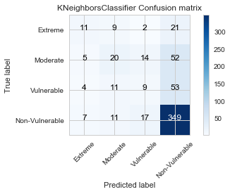

```python
# K-Nearest Neighbors

from sklearn.neighbors import KNeighborsClassifier

knc_hyper_parameters = {'n_neighbors': [2, 5, 8, 16],
                       'weights': ['uniform', 'distance'],
                       'algorithm': ['auto', 'ball_tree', 'brute', 'kd_tree'],
                       'p': [1, 2]}

knc_clf_res = train_predict(KNeighborsClassifier(),
                            f1_weighted_scorer,
                            knc_hyper_parameters, X_train, y_train, X_test, y_test)

output_classifier_results('KNeighborsClassifier', knc_clf_res)
```

```
completed training using SVC classifier
train_time: 52.32307052612305
pred_time: 0.11794590950012207
accuracy: 0.3150860767139837
f1_score: 0.03772981097185619
Confusion matrix, without normalization
[[ 38   0   5   0]
 [ 74   0  17   0]
 [ 48   0  29   0]
 [201   0 183   0]]
```

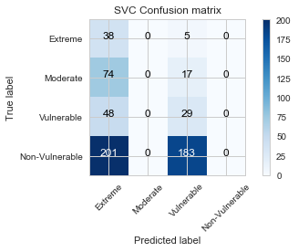

```python
# SVM

from sklearn.svm import SVC

svc_hyper_parameters = {'gamma': [0.001, 0.01],
                       'degree': [3, 5],
                       'kernel': ['rbf', 'poly'],
                       'C': [0.5, 1.5],
                       'max_iter': [100, 200]}

svc_clf_res = train_predict(SVC(random_state = 42, class_weight = 'balanced', decision_function_shape = 'ovo'),
                            f1_weighted_scorer,
                            svc_hyper_parameters, X_train, y_train, X_test, y_test)

output_classifier_results('SVC', svc_clf_res)
```

```
completed training using AdaBoostClassifier classifier
train_time: 116.34204483032227
pred_time: 0.0639963150024414
accuracy: 0.3735893920759473
f1_score: 0.6230627489746989
Confusion matrix, without normalization
[[  7  15   1  20]
 [  4  29   4  54]
 [  3  10   4  60]
 [  3   9   3 369]]
```

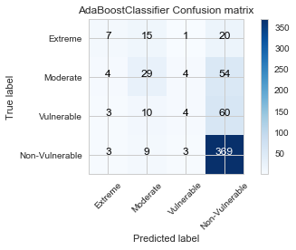

```python
# AdaBoost

from sklearn.ensemble import AdaBoostClassifier

abc_hyper_parameters = {'n_estimators': [150, 250, 350, 450],
                       'learning_rate': [0.5, 1.0, 1.5],
                       'algorithm': ['SAMME', 'SAMME.R']}

abc_clf_res = train_predict(AdaBoostClassifier(random_state = 42),
                            f1_weighted_scorer,
                            abc_hyper_parameters, X_train, y_train, X_test, y_test)

output_classifier_results('AdaBoostClassifier', abc_clf_res)
```

```
completed training using XGBClassifier classifier
train_time: 16.615920782089233
pred_time: 0.008001089096069336
accuracy: 0.3873261852004585
f1_score: 0.6236433538441488
Confusion matrix, without normalization
[[ 12  10   1  20]
 [ 10  22   3  56]
 [  4   8   5  60]
 [  2   9   3 370]]
```

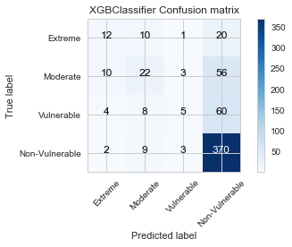

```python
# XGBoost

from xgboost import XGBClassifier

# clear from the output numpy warning
import warnings
warnings.filterwarnings("ignore")

xgbc_hyper_parameters = {'objective': ['binary', 'logistic']}

xgbc_clf_res = train_predict(XGBClassifier(random_state = 42, n_jobs = 5),
                            f1_weighted_scorer,
                            xgbc_hyper_parameters, X_train, y_train, X_test, y_test)

output_classifier_results('XGBClassifier', xgbc_clf_res)
```

[output not shown]

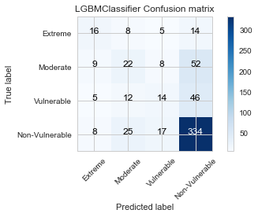

```python
# LightGBM

from lightgbm import LGBMClassifier

lgbmc_hyper_parameters = {'learning_rate': [0.5, 1.0, 1.5],
                          'n_estimators': [150, 250, 350, 450]}

lgbmc_clf_res = train_predict(LGBMClassifier(random_state = 42, n_jobs = 5, class_weight = 'balanced'),
                            f1_weighted_scorer,
                            lgbmc_hyper_parameters, X_train, y_train, X_test, y_test)

output_classifier_results('LGBMClassifier', lgbmc_clf_res)
```

### Results Comparison

```python
# collecting all results into a single DF

indexes = ['model', 'train_time', 'accuracy', 'f1_score']

algorithms = ['NaiveClassifier', 'RandomForestClassifier', 'GaussianNB', 'DecisionTreeClassifier', 'KNeighborsClassifier',
             'SVC', 'AdaBoostClassifier', 'XGBClassifier', 'LGBMClassifier']

results = [naive_clf_res, rf_clf_res, gnb_clf_res, dtc_clf_res, knc_clf_res, svc_clf_res, abc_clf_res,
          xgbc_clf_res, lgbmc_clf_res]

train_time = []
accuracy = []
f1_score = []

for clf_result in results:
    train_time.append(clf_result['train_time'])
    accuracy.append(clf_result['accuracy'])
    f1_score.append(clf_result['f1_score'])


all_results = pd.DataFrame({'train_time': train_time,
                            'accuracy': accuracy,
                            'f1_score': f1_score},
                           index=algorithms)

all_results
```

|  | train_time | accuracy | f1_score |
| --- | --- | --- | --- |
| NaiveClassifier | 0.019997 | 0.250000 | 0.506282 |
| RandomForestClassifier | 78.468028 | 0.484508 | 0.632653 |
| GaussianNB | 0.106993 | 0.311762 | 0.224977 |
| DecisionTreeClassifier | 5.605005 | 0.460114 | 0.532285 |
| KNeighborsClassifier | 149.457093 | 0.375333 | 0.609787 |
| SVC | 52.323071 | 0.315086 | 0.037730 |
| AdaBoostClassifier | 116.342045 | 0.373589 | 0.623063 |
| XGBClassifier | 16.615921 | 0.387326 | 0.623643 |
| LGBMClassifier | 56.478029 | 0.416365 | 0.620501 |

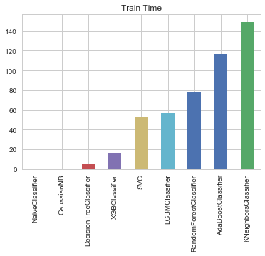

```python
ax = all_results.sort_values('train_time', ascending=True).plot(y='train_time', kind="bar", title='Train Time', legend = False)
```

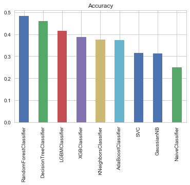

```python
ax = all_results.sort_values('accuracy', ascending=False).plot(y='accuracy', kind="bar", title='Accuracy', legend = False)
```

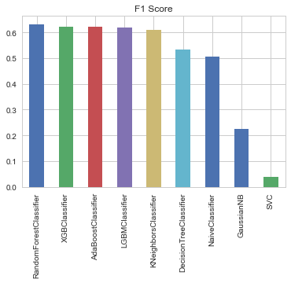

```python
ax = all_results.sort_values('f1_score', ascending=False).plot(y='f1_score', kind="bar", title='F1 Score', legend = False)
```

We can first see that because of the *high imbalance* of the data, the **Naive classifier performed better than some of the other algorithms** (namely GaussianNB and SVC). This is a possible outcome of my tests because using a single classifier for a problem with relatively small amount of samples and relatively higher number of features may be difficult.

While the Naive classifier "exceled" in F1 score, it did prove much worse when looking on its accuracy, and this also makes sense because it gave wrong predictions for all the targets which are not 4. BTW, if we would have given a "higher" weight to predicting correctly the targets 1 and 2 (extreme poverty and poverty), the Naive classifier would get even lower values.

We can also see that all the classifiers that use some **combination** of estimators (random forrest, XGB, Ada Boost and LGBM) produced better F1 scores, and in some cases even better accuracy compared to the Naive classifier!

If i had to choose which algorithm should be taken for making predictions for this problem, i would take either **Random Forest** or **LGB**, as they both gave good accuracy and F1 score results compared to the others (they are in the top 4 in both metrics).

```python
# print out the parameters of the best models

print("Random Forest best parameters:")
print(rf_clf_res['best_params'])

print("LGBM best parameters:")
print(lgbmc_clf_res['best_params'])
```

```
Random Forest best parameters:
{'criterion': 'gini', 'max_depth': 8, 'min_samples_leaf': 2, 'min_samples_split': 2, 'n_estimators': 150}
LGBM best parameters:
{'learning_rate': 1.5, 'n_estimators': 250}
```

### Principle Component Analysis

I will try now to use PCA for performing dimensionality reduction, and see if using one of the best algorithms i've found so far will perform better using the reduced data.

```python
from sklearn.decomposition import PCA

for i in range(40):

    # apply PCA on the scaled features
    pca = PCA(n_components=i+1)
    pca.fit(scaled_features)

    # print the explained variance for each component
    print("The total explained variance of {} components is {}".format(i+1, sum(pca.explained_variance_ratio_)))
```

```
The total explained variance of 1 components is 0.16952593103951935
The total explained variance of 2 components is 0.2468064790640931
The total explained variance of 3 components is 0.309042214965267
The total explained variance of 4 components is 0.3634574712177324
The total explained variance of 5 components is 0.4106592057582478
The total explained variance of 6 components is 0.45286833992949505
The total explained variance of 7 components is 0.4923669191790893
The total explained variance of 8 components is 0.5258225434935194
The total explained variance of 9 components is 0.558235966204109
The total explained variance of 10 components is 0.5875515047795395
The total explained variance of 11 components is 0.6140986508688463
The total explained variance of 12 components is 0.6362969103124954
The total explained variance of 13 components is 0.657384102562879
The total explained variance of 14 components is 0.676314239148113
The total explained variance of 15 components is 0.6939065060123978
The total explained variance of 16 components is 0.7113751577690933
The total explained variance of 17 components is 0.7281068738134664
The total explained variance of 18 components is 0.7437007049981127
The total explained variance of 19 components is 0.7581862150356704
The total explained variance of 20 components is 0.7716223104321759
The total explained variance of 21 components is 0.783830679770093
The total explained variance of 22 components is 0.7954389560935019
The total explained variance of 23 components is 0.8067154405957446
The total explained variance of 24 components is 0.8173823513584404
The total explained variance of 25 components is 0.8272396535448112
The total explained variance of 26 components is 0.8373377013946658
The total explained variance of 27 components is 0.8464847168028264
The total explained variance of 28 components is 0.8553246829978491
The total explained variance of 29 components is 0.8633897842572038
The total explained variance of 30 components is 0.8714252521665883
The total explained variance of 31 components is 0.8790029393843459
The total explained variance of 32 components is 0.8862968091992198
The total explained variance of 33 components is 0.8932010368022505
The total explained variance of 34 components is 0.8997511640665291
The total explained variance of 35 components is 0.9057300720766548
The total explained variance of 36 components is 0.9111940179123035
The total explained variance of 37 components is 0.9163029301808078
The total explained variance of 38 components is 0.921384386013001
The total explained variance of 39 components is 0.9260447877831054
The total explained variance of 40 components is 0.9305462409110655
```

So 35 components explain ~90% of the variance. So we can use that for our feature reduction.

```python
pca = PCA(n_components=35)
pca.fit(scaled_features)

reduced_data = pca.transform(scaled_features)
pca_columns = []

for i in range(35):
    pca_columns.append('Dimension {}'.format(i+1))

# Create a DataFrame for the reduced data
reduced_data = pd.DataFrame(reduced_data, columns = pca_columns)
reduced_data.shape
```

```
(2973, 35)
```

```
completed training using RandomForestClassifier classifier
train_time: 182.7970950603485
pred_time: 0.023973464965820312
accuracy: 0.40285656083257826
f1_score: 0.6195549435044345
Confusion matrix, without normalization
[[  9  17   8   9]
 [  8  39   9  35]
 [  5  24  12  36]
 [ 10  39  21 314]]
```

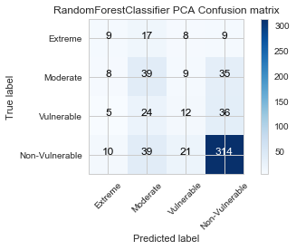

```python
# now let's re-use the Random forest and LGB classifiers on the reduced data, and see if\how the results change
reduced_X_train, reduced_X_test, reduced_y_train, reduced_y_test = train_test_split(reduced_data,
                                                    target_labels,
                                                    test_size = 0.2,
                                                    random_state = 42)

reduced_rf_clf_res = train_predict(RandomForestClassifier(random_state = 42, class_weight = 'balanced'),
                            f1_weighted_scorer,
                            rf_hyper_parameters, reduced_X_train, reduced_y_train, reduced_X_test, reduced_y_test)

output_classifier_results('RandomForestClassifier PCA', reduced_rf_clf_res)
```

```
completed training using LGBMClassifier classifier
train_time: 74.40500497817993
pred_time: 0.029999494552612305
accuracy: 0.37116104280893525
f1_score: 0.6133645557739802
Confusion matrix, without normalization
[[  9  12   3  19]
 [  8  22   5  56]
 [  3  11   8  55]
 [  5  16   6 357]]
```

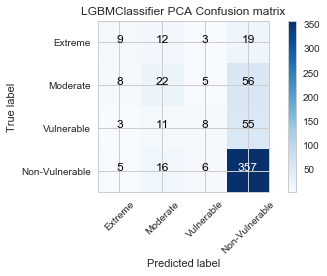

```python
reduced_lgbmc_clf_res = train_predict(LGBMClassifier(random_state = 42, n_jobs = 5, class_weight = 'balanced'),
                            f1_weighted_scorer,
                            lgbmc_hyper_parameters,reduced_X_train, reduced_y_train, reduced_X_test, reduced_y_test)

output_classifier_results('LGBMClassifier PCA', reduced_lgbmc_clf_res)
```

If we compare the results to those on the original feature set, we see the following:

**Random Forest**:

*accuracy score*: on the original feature set = 0.484508, on the reduced feature set = 0.40285656083257826

*F1 score*: on the original feature set = 0.632653, on the reduced feature set = 0.6195549435044345

**LGBM**:

*training time*: on the original feature set = 56.478029 , on the reduced feature set = 74.40500497817993

*accuracy score*: on the original feature set = 0.416365, on the reduced feature set = 0.37116104280893525

*F1 score*: on the original feature set = 0.620501, on the reduced feature set = 0.6133645557739802

So the training time was actually worse on the reduced feature set, but this might be related to the fact that the data set is relatively very small, so any number of other running processes running on my test environment could have an affect on this number. I assume that on a much larger data sets we would see an improve in the training execution time.

Looking overall on the results, I think that in this case **PCA can be used on the original data**, because we have a relatively large number of features compared to very small data set (few thousand rows). Using the data set as is will make classifiers harder to learn from the data, as there are too few rows to learn from about feature importance, feature correlations.

We can see that we "loose" relatively small values in the F1 score values, and gain using 35 features instead of 131 features.

If this was a larger dataset (in terms of number of rows), keeping the features would have made more sense, as it would have enabled the classifiers to learn more easily.